# r-pkgs

Hugh Parsonage  
2017-10-24

### R packages

Why packages?

- Iterating is hard
- Copying and pasting is a lot more difficult than you might think
- Packages are fast and portable
- Packages force best practice:
  - unit test suites
  - documentation of datasets and functions

### Types of packages

Data packages:

- `taxstats`
- `sih.hilda.1314`
- `sihData` `hildaData`
- `Census2016`, `Census2016.DataPack`
- `ASGS`
- `nsw.property.sales`

### Types of packages

Other packages:

- `grattan`
- `PSMA`
- `sihExtra` `hildaExtra`
- `grattanReporter`
- `TeXCheckR`
- `grattanCharts`
- `bomrang`

## Tax packages

### `grattan v1.5.2.3`

```r
library(grattan)
```

Semantic versioning with data update suffix

`grattan vX.Y.Z.d`:

- `X` increments on non-backwards-compatible changes
- `Y` increments on new feature
- `Z` increments on bug-fixes
- `d` increments on data updates from ABS (at least every month)

### `taxstats v0.0.4.1314`

Semantic versioning with non-standard data suffix: `1314` will increment to `1415` when the 2014-15 sample file is released.

Not on CRAN. Use my repository: https://hughparsonage.github.io/drat

- Lazily loads the 2% sample files for the 2011-12, 2012-13, 2013-14 personal income tax collections and 1% sample files since 2003-04
- Table 1 for selected items, individual 1979-2014

```r
library(data.table)
library(taxstats)
get_sample_files_all()[, .(median_taxable_income = median(Taxable_Income)), by = "fy.year"]
```

```
    fy.year median_taxable_income
 1: 2003-04               28611.5
 2: 2004-05               29782.0
 3: 2005-06               30946.0
 4: 2006-07               32108.0
 5: 2007-08               33263.0
 6: 2008-09               34749.0
 7: 2009-10               35598.5
 8: 2010-11               37865.0
 9: 2011-12               39848.0
10: 2012-13               41561.0
11: 2013-14               42237.0
```

| fy.year | median_taxable_income |
| --- | --- |
| 2003-04 | 28611.5 |
| 2004-05 | 29782.0 |
| 2005-06 | 30946.0 |
| 2006-07 | 32108.0 |
| 2007-08 | 33263.0 |
| 2008-09 | 34749.0 |
| 2009-10 | 35598.5 |
| 2010-11 | 37865.0 |
| 2011-12 | 39848.0 |
| 2012-13 | 41561.0 |
| 2013-14 | 42237.0 |

### `taxstats v0.0.4.1314`

- Table 1 for selected items, individual 1979-2014

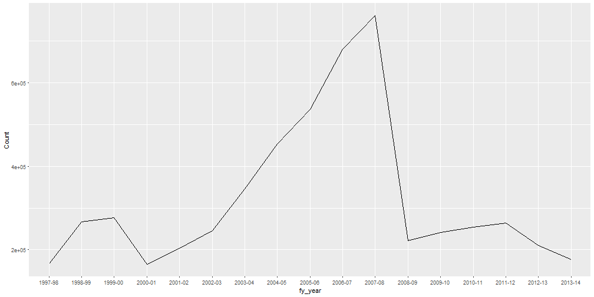

```r
individuals_table1_201314 %>% .[Selected_items == "Medicare levy surcharge"] %>% .[complete.cases(.)] %>% ggplot(aes(x = fy_year, y = Count)) + geom_line(group = 1)
```

### sih.hilda.1314

Convenience package for wealth and income data from the 2013-14 series of HILDA and SIH:

```
> svy_id_income
       survey         id_hh        income_type    income
    1:  hilda        100001 disposable regular 1*****.00
    2:  hilda        100001   disposable total 1*****.00
    3:  hilda        100001        gross total 1-----.00
    4:  hilda        100001      gross regular 1-----.00
    5:  hilda        100011 disposable regular  8****.00
   ---
94796:  sih13 SIH13E8999997        gross total 1*****.02
94797:  sih13 SIH13E8999998 disposable regular      0.00
94798:  sih13 SIH13E8999998   disposable total  9****.82
94799:  sih13 SIH13E8999998      gross regular  *****.35
94800:  sih13 SIH13E8999998        gross total  9****.17
```

Needs to be installed from source.

### sihData hildaData

Houses the data from each series.

### Census2016 0.2.0

Initial version of Census time series data. On CRAN. Will be promoted to 1.0.0 and frozen in the new year following data updates.

```r
library(Census2016)
```

Contains, for each SA2, and the 2006, 2011, 2016 years, the time-series profiles.

### Census2016 0.2.0

```r
Census2016_wide_by_SA2_year %>%
  .[, .(sa2_name, year, born_in_australia)]
```

```
            sa2_name year born_in_australia
   1:      Braidwood 2006              2910
   2:      Braidwood 2011              2711
   3:      Braidwood 2016              2948
   4:        Karabar 2006              7214
   5:        Karabar 2011              6737
  ---
6716:     Jervis Bay 2011               341
6717:     Jervis Bay 2016               299
6718: Norfolk Island 2006                NA
6719: Norfolk Island 2011                NA
6720: Norfolk Island 2016              1069
```

Use `see_question()` in RStudio to view the question associated with a table.

### Census2016.DataPack 0.1.0

Large package, contains the data packs from the 2016 Census. Greater detail, at all the statistical areas.

Enhanced by the autocompletion features in RStudio IDE. Type `SA2__` and then scroll to the table of interest.

Motivated by arcane column names in the data packs (*e.g.* `Se_d_r_or_t_h_t_Tot_NofB_0_ib`)

```r
library(Census2016.DataPack)
SA2__CountryOfBirth_YearOfArrival
```

```
                    SA2_NAME16   CountryOfBirth YearOfArrival
      1:             Braidwood (Born elsewhere)            NA
      2:             Braidwood (Born elsewhere)          1946
      3:             Braidwood (Born elsewhere)          1955
      4:             Braidwood (Born elsewhere)          1965
      5:             Braidwood (Born elsewhere)          1975
     ---
1212746: No usual address (OT)         Zimbabwe          2012
1212747: No usual address (OT)         Zimbabwe          2013
1212748: No usual address (OT)         Zimbabwe          2014
1212749: No usual address (OT)         Zimbabwe          2015
1212750: No usual address (OT)         Zimbabwe          2016
         persons_born_overseas
      1:                     3
      2:                     0
      3:                     4
      4:                     6
      5:                    25
     ---
1212746:                     0
1212747:                     0
1212748:                     0
1212749:                     0
1212750:                     0
```

### nsw.property.sales

Every property sale in NSW since 1990, in a tidy form and land value information (forthcoming).

- Original data is about 80,000 files in a bespoke format (haven't found a program that can open them directly — the website says that you can open them in Excel, but it's not true, and even so you can only open them one at a time).
- Original data has weird headings and things like zoning code change over time

### `grattan v1.5.2.3`

Major updates occur at least as frequently as the Budget.

### `grattan v1.5.2.3`

Mainly useful when analysing the sample files:

- `project()` takes a sample file and forecasts every variable in it in a reasonable way. For example work-related expenses are inflated by the appropriate index in the consumer price series; salaries are inflated by the wage price index; the number of taxpayers by the labour force index. Forecasts are performed on sample files in the future:

```r
sample_file_1819 <- project(sample_file_1314, h = 5L) # horizon = 5 years
```

### `grattan v1.5.2.3`

Mainly useful when analysing the sample files:

- `income_tax()` calculates the income tax, including the Medicare levy, and all offsets that are possible to calculate using the sample file. Nice and quick: 10M/s. Treasury's CAPITA does more but *only* on variables we can't access.

```r
sample_file_1314[, tax := income_tax(Taxable_Income, "2013-14")]
```

### `grattan v1.5.2.3`

Similarly:

- `medicare_levy()`. Calculating the Medicare levy is *very* complicated. Requires sifting through many tax rulings over decades to properly calculate. ATO public fact sheets are not only dense but frequently *wrong*.
- `sapto()` and `bto()`: similarly very difficult. (Treasury annoyingly admits in CAPITA they have to assume away details on how s.160AAAA(4)(b) is meant to operate.) `lito()` not so much but easy to mess up.
- `student_repayment()`: calculates HECS/HELP/etc repayment

### `grattan v1.5.2.3`

Other more common but easier utilities:

```r
cpi_inflator(from_fy = "2012-13", to_fy = "2015-16")
```

```
[1] 1.056641
```

### `grattan v1.5.2.3`

Other more common but easier utilities:

```r
wage_inflator(from_fy = "2012-13", to_fy = "2015-16")
```

```
[1] 1.070873
```

### `grattan v1.5.2.3`

Other more common but easier utilities:

```r
lf_inflator_fy(from_fy = "2012-13", to_fy = "2015-16")
```

```
[1] 1.045195
```

Also `weighted_ntile` for creating quantiles on weighted data

### `grattan v1.5.2.3`

Superannuation modelling:

```r
apply_super_caps_and_div293(.sample.file,
                            div293_threshold = 200e3,
                            cap = 20e3,
                            age_based_cap = FALSE)
```

## Australian geography

### `ASGS`

Big package (1 GB):

- Houses 2011-2016 shapefiles: SA[1-4], postcodes, LGAs, destination zones, states, as well as simplified/lighter versions for the web etc
- `grattan_leaflet()` produces interactive maps of a table of location vs variable in Grattan palette
- Functions for converting lat-lons to the statistical area containing it.

### PSMA

address —> lat-lon:

```r
library(PSMA)
geocode(number_first = 8,
        street_name = "Malvina",
        street_type = "Place",
        postcode = 3053)
```

```
   ordering  LATITUDE LONGITUDE
1:        1 -37.80058  144.9618
```

First query in a session takes a few seconds (to load the lookup tables). Doesn't take much longer to do a few million addresses.

### PSMA

address <— lat-lon:

```r
library(PSMA)
revgeocode(-37.80058, 144.9618)
```

```
      distance ordering NUMBER_FIRST STREET_NAME STREET_TYPE_CODE POSTCODE
1: 0.002640044        1           10     MALVINA            PLACE     3053
   order BUILDING_NAME LOT_NUMBER FLAT_NUMBER ADDRESS_DETAIL_INTRNL_ID
1:     1            NA         NA          NA                  9393231
```

## LaTeX utilities

### grattanReporter and TeXCheckR

`grattanReporter` depends on `TeXCheckR`. The latter is on CRAN and is more general.

Highlights:

- In RStudio, encountering an error 'pops' the cursor to the location of the error (and copies to the clipboard a suggested spelling for `check_spelling`)
- `fread_bib` for queries on the master bibliography *e.g.* all entries by a particular author
- `extract_LaTeX_argument`: how many times has an author been cited? Get all figure paths.

## Charts

### grattanCharts

On GitHub:

```r
library(grattanCharts)
```

- `annotate_coastline`: overlays the coastline to a map
- `bundle_chart_data()` and `chart_data()` dynamically produce chart data packs (provided they're simple enough to be passed to the Excel API)
- Contains for convenience, the dimensions of reports, including the aspect ratios of charts
- Palette `gpal()` and extended palette `gpalx()`

### grattanCharts

- English conversions of numbers

```r
grattan_frac(0.51)
```

```
[1] "over one-half"
```

```r
grattan_frac(0.49)
```

```
[1] "almost one-half"
```

```r
grattan_frac(0.49, hedges = c("under", "over"))
```

```
[1] "under one-half"
```

### grattanCharts

- English conversions of numbers

```r
texNum(235709234)
```

```
[1] "0.236~billion"
```

```r
texNum(235709234, .suffix = "million")
```

```
[1] "236~million"
```

### grattanCharts

- `grplot` for grattan-style charts using `ggplot2`
- `save_pptx` for conversion to presentation or report-style templates
- `grattan_waterfall` for a very simple interface to create (better) waterfall charts

## Miscellaneous

### hutils

General R programming utilities

Not much direct application to policy, but `haversine_distance` may be useful – calculates distance between two points on the Earth with reasonable accuracy.

### bomrang

Get weather data through the BOM API:

- `get_current_weather()` weather in the last 72 hours at a particular station (fuzzily matched), or the nearest station to lat-lon
- You have to buy data from earlier than 72 hours, but there's probably nothing to stop you downloading it every 3 days.
- `get_precis_forecast()` 7-day forecasts